```python
# Originally created on 2024-01-24 by Hiroyuki Tako ISHIKAWA

# Purpose:
#   Check if the high-resolution spectra of our target candidate UCDs are available in the telescope archives.

# ------- SETTINGS -------
# Please edit the paths below:
path_fig = '/Users/chonmac/Dropbox/tmpfig/'
path_llp2024 = "/Users/chonmac/Downloads/archive_search_for_Gemini_LLP2024/"
oldoriginal_path_sami_table = path_llp2024 + "everything_01_08_2024_Sami.csv"
path_sami_table = path_llp2024 + "everything_02_28_2024_Sami.csv"
path_KOA = path_llp2024 + "KOA/" #Keck Observatory Archive (KOA)
path_ESO = path_llp2024 + "ESO/" #ESO Science Archive Facility (ESO SAF)
path_tableC1_Nagel23 = "/Users/chonmac/Downloads/Nagel_2023_CDS_CARMENES_382Mdwarfs_templates/tablec1_Nagel_2023.dat" #CARMENES
# ------------------------

import numpy as np
%matplotlib widget
import matplotlib.pyplot as plt
import pandas as pd
pd.set_option('display.max_rows', 20) #, None)
pd.set_option('display.max_columns', None)
tcp = ['#005493', '#FFD479', '#FF5F7F', '#47ACA9', '#D9D2E9', '#F2E4C9', ] #Tako Color
```

# Read parent sample from Sami's list

and Remove known binaries

```python
#chk
print(
    np.setdiff1d(pd.read_csv(path_llp2024 + "everything_01_08_2024_Sami.csv", low_memory=False).columns, pd.read_csv(path_llp2024 + "everything_02_28_2024_Sami.csv", low_memory=False).columns),
    np.setdiff1d(pd.read_csv(path_llp2024 + "everything_02_28_2024_Sami.csv", low_memory=False).columns, pd.read_csv(path_llp2024 + "everything_01_08_2024_Sami.csv", low_memory=False).columns) )
```

```
['binary_flag'] ['not_binary']
```

```python
if "everything_01_08_2024_Sami" in path_sami_table:
    df_every = pd.read_csv(path_sami_table, low_memory=False)#, index_col=0)
    df_single = df_every[df_every["binary_flag"]==False].reset_index(drop=True)
elif "everything_02_28_2024_Sami" in path_sami_table:
    df_every_rev = pd.read_csv(path_sami_table, low_memory=False)#, index_col=0)
    df_single_rev = df_every_rev[df_every_rev["not_binary"]==True].reset_index(drop=True)
    df_every_old = pd.read_csv(path_llp2024 + "everything_01_08_2024_Sami.csv", low_memory=False)#, index_col=0)
    df_single_old = df_every_old[df_every_old["binary_flag"]==False].reset_index(drop=True)

    df_every = pd.read_csv(oldoriginal_path_sami_table, low_memory=False)#, index_col=0)
    df_single = df_every[df_every["binary_flag"]==False].reset_index(drop=True)

df_grv = pd.read_csv(path_llp2024 + "gaia_rvs_Sami240222.csv")
df_grv_ex = df_grv.iloc[np.where(~df_grv["radial_velocity_error"].isna())[0]].reset_index(drop=True) #radial_velocity, rv_method_used, grvs_mag

#chk
df_single_rev.shape, np.unique(df_single_rev["gaia_source_id"]).shape
```

```
((3951, 146), (3951,))
```

Skip to Read in search results from multiple archives

```python
""" Sami:
There are 835 targets in this list missing Gaia
photometry - either G, BP, RP, or a combination
of these. The vast majority of these targets
(~96-98%) are most likely not ultracool dwarfs.
"""

print( len(np.where(df_every_rev["DR3_G_mag"].isna())[0]) )
print( len(np.where(df_every_rev["DR3_BP_mag"].isna())[0]) )
print( len(np.where(df_every_rev["DR3_RP_mag"].isna())[0]) )

print( len(np.where(df_single_rev["DR3_G_mag"].isna())[0]) )
print( len(np.where(df_single_rev["DR3_BP_mag"].isna())[0]) )
print( len(np.where(df_single_rev["DR3_RP_mag"].isna())[0]) )

df_single_gaiaphoto = df_single_rev[~df_single_rev["DR3_G_mag"].isna()]
df_single_gaiaphoto = df_single_gaiaphoto[~df_single_gaiaphoto["DR3_BP_mag"].isna()]
df_single_gaiaphoto = df_single_gaiaphoto[~df_single_gaiaphoto["DR3_RP_mag"].isna()]

print(df_single_gaiaphoto.shape) #chk
```

```
21
834
810
21
834
810
(3116, 146)
```

# Function to convert coordinates

```python
from astropy.coordinates import SkyCoord
import astropy.units as u

def convert_to_sexagesimal(ra_deg, dec_deg, format_hskymon=False):
    """Convert RA DEC from decimal degrees to sexagesimal hours and sexagesimal degrees
    Args:
        ra_deg (float): Right Ascension in decimal degrees.
        dec_deg (float): Declination in decimal degrees.
        format_hskymon (bool): If True, format for hskymon (no colons).
    Returns:
        tuple: RA in sexagesimal hours and DEC in sexagesimal degrees.
    """

    # Create a SkyCoord object with RA and DEC in decimal degrees
    coord = SkyCoord(ra_deg, dec_deg, unit=(u.deg, u.deg), frame='icrs')

    # Convert to sexagesimal format
    ra_sexagesimal = coord.ra.to_string(unit=u.hour, sep=':')
    dec_sexagesimal = coord.dec.to_string(unit=u.degree, sep=':')

    if format_hskymon:
        ra_sexagesimal = ra_sexagesimal.replace(":", "")
        dec_sexagesimal = dec_sexagesimal.replace(":", "")

    return ra_sexagesimal, dec_sexagesimal


# Example usage # Uncomment to use

# ra_decimal = 187.7042 #10.68458  # Example RA in decimal degrees
# dec_decimal = 12.3962 #41.26917 # Example DEC in decimal degrees
# ra_sexagesimal, dec_sexagesimal = convert_to_sexagesimal(ra_decimal, dec_decimal)
# print("RA in sexagesimal:", ra_sexagesimal, "(", ra_sexagesimal.replace(":", ""), ")")
# print("DEC in sexagesimal:", dec_sexagesimal, "(", dec_sexagesimal.replace(":", ""), ")")
# print(f'{float(ra_sexagesimal.replace(":", "")):0>10.3f}', f'{float(dec_sexagesimal.replace(":", "")):0>9.2f}')

# # Validate the function "convert_to_sexagesimal" and See the change of position from 2MASS to Gaia #test240125
# df_sample = df_single[df_single["gaia_source_id"]==3864972938605115520]
# print(df_sample["2mass_id"], df_sample["2mass_ra"], df_sample["2mass_dec"], df_sample["gaia_ra"], df_sample["gaia_dec"])
# print(convert_to_sexagesimal(df_sample["2mass_ra"], df_sample["2mass_dec"]))
# print(convert_to_sexagesimal(df_sample["gaia_ra"], df_sample["gaia_dec"]))
```

# KOA

## KOA; Prepare input file to upload

```python
# Separate all the targets into multiple files each including 999 (for the 1000 rows limitation in the KOA webpage)
for i in np.arange(5):
    range_trim = [i*999, (i+1)*999]
    df_single_3data = pd.concat([df_single[range_trim[0]:range_trim[1]]["gaia_source_id"], df_single[range_trim[0]:range_trim[1]]["gaia_ra"], df_single[range_trim[0]:range_trim[1]]["gaia_dec"]], axis=1)
    df_single_input_KOA = df_single_3data.rename(columns={'gaia_source_id': 'object', 'gaia_ra': 'ra', 'gaia_dec':'dec'})
    df_single_input_KOA.to_csv(path_KOA + f'table_KOA_sample{i:0>2}.txt', header=True, index=False, sep=',')
```

## KOA; Read Results

Enter each of the above input files one by one at  
http://koa.ipac.caltech.edu/applications/KOA  
and load the (integrated) output below to integrate it into our database (which was based on Sami's parent sample).

```python
df_KOAres = pd.read_csv(path_KOA + "table_KOA_results00to04.txt", index_col=0, sep="\t")
```

[output not shown]

```python
#for i in np.arange(5): #Uncomment here and indent the four lines below if you want to read the results one by one
df_KOAres = pd.read_csv(path_KOA + "table_KOA_results00to04.txt", index_col=0, sep="\t")
df_KOAres_true = df_KOAres[df_KOAres["Status"]=="OK"]
print(df_KOAres.shape, df_KOAres_true.shape) #chk

#chk
# df_KOAres_true[["Object", "RA", "Dec", "HIRES", "NIRSPEC"]]

# Add new lines to the parent sample list　to store the result of KOA archive-data search
df_single_KOA = df_single.assign(archivedata_KOA=0)
df_single_KOA = df_single_KOA.assign(archivedata_HIRES=0)
df_single_KOA = df_single_KOA.assign(archivedata_NIRSPEC=0)

# Switch 0 to the number of available frames if the object has high-res spectra in KOA
i_column = np.where(df_single_KOA.keys() == "archivedata_KOA")[0][0]
for i, obj in enumerate(df_KOAres_true["Object"]): #[:5]:
    #print()
    #print(obj)
    #print(df_single[df_single["gaia_source_id"]==obj][["2mass_id", "j_mag", "DR3_G_mag", "bp_rp", "teff_k"]])
    i_row = np.where(df_single_KOA["gaia_source_id"]==obj)[0][0]
    num_frame_KOA = np.array(df_KOAres_true["HIRES"])[i] + np.array(df_KOAres_true["NIRSPEC"])[i]
    df_single_KOA.iloc[i_row, i_column] = num_frame_KOA
    df_single_KOA.iloc[i_row, i_column+1] = np.array(df_KOAres_true["HIRES"])[i]
    df_single_KOA.iloc[i_row, i_column+2] = np.array(df_KOAres_true["NIRSPEC"])[i]

#chk
arr_KOA = np.array(df_single_KOA["archivedata_KOA"])
arr_hir = np.array(df_single_KOA["archivedata_HIRES"])
arr_nir = np.array(df_single_KOA["archivedata_NIRSPEC"])
print( np.all(arr_KOA == arr_hir+arr_nir) )

#df_single_KOA.to_csv(path_llp2024 + 'df_single_KOA.csv')

#chk
df_single_KOA.columns[-3:]
```

```
(4078, 31) (210, 31)
True
```

```
Index(['archivedata_KOA', 'archivedata_HIRES', 'archivedata_NIRSPEC'], dtype='object')
```

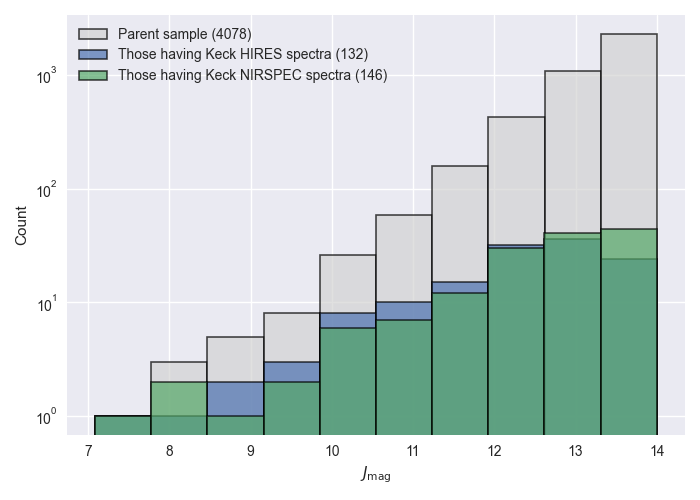

```python
# print(plt.style.available)
#plt.style.use('bmh')
plt.style.use('seaborn-v0_8')
#plt.style.use('default')

df_single_onlythose_have_KOA = df_single_KOA[df_single_KOA["archivedata_KOA"] >= 1]
df_single_onlythose_have_HIRES = df_single_KOA[df_single_KOA["archivedata_HIRES"] >= 1]
df_single_onlythose_have_NIRSPEC = df_single_KOA[df_single_KOA["archivedata_NIRSPEC"] >= 1]
arr_jmag_parent = np.array(df_single_KOA["j_mag"])
arr_jmag_koa = np.array(df_single_onlythose_have_KOA["j_mag"])
arr_jmag_hir = np.array(df_single_onlythose_have_HIRES["j_mag"])
arr_jmag_nir = np.array(df_single_onlythose_have_NIRSPEC["j_mag"])

fig, ax = plt.subplots(figsize=(7, 5), tight_layout=True)
ax.hist(arr_jmag_parent, alpha=0.7, label=f"Parent sample ({len(arr_jmag_parent)})", color="lightgray", edgecolor='black', linewidth=1.2)
#ax.hist(arr_jmag_koa, alpha=0.8, label=f"Those having Keck high-R spectra ({len(arr_jmag_koa)})", edgecolor='black', linewidth=1.2)
ax.hist(arr_jmag_hir, alpha=0.7, label=f"Those having Keck HIRES spectra ({len(arr_jmag_hir)})", edgecolor='black', linewidth=1.2)
ax.hist(arr_jmag_nir, alpha=0.7, label=f"Those having Keck NIRSPEC spectra ({len(arr_jmag_nir)})", edgecolor='black', linewidth=1.2)
plt.ylabel("Count")
plt.xlabel("$J_\mathrm{mag}$")
plt.yscale("log")
#plt.tick_params(direction='in', which='both')
#plt.minorticks_on()
#plt.grid(which='both', alpha=0.20)
plt.legend(loc="best")
#plt.savefig(path_llp2024 + "histogram_Jmag14_Keck.pdf")
plt.show()
```

# ESO SAF

reference: http://archive.eso.org/eso/eso_archive_help.html#Upload

```python
fname_input_ESO = 'table_ESO_sample_all.txt'
```

## ESO; Prepare input file to upload

```python
df_single_input_ESO = pd.concat([df_single[:]["gaia_ra"], df_single[:]["gaia_dec"]], axis=1)
df_single_input_ESO.to_csv(path_ESO + fname_input_ESO, header=False, index=False, sep='\t')
```

## ESO; Read Results

Searched instruments: CRIRES, ESPRESSO, UVES (VLT), FEROS, HARPS, NIRPS (LaSilla)  
[ESO_SAF_query_ScS240131.png](https://u.pcloud.link/publink/show?code=XZi0sB5Zc7Gsqc7tU3SlKLrehzcDMydgD6JV)

```python
fname_output_ESO = fname_input_ESO.split(".")[0] + "_eso.txt"
with open(path_ESO + fname_output_ESO, "r") as f_eso_op:
    lines_eso_op = f_eso_op.readlines()



#df_ESOres = pd.read_csv(path_ESO + fname_output_ESO)#, index_col=0, sep="\t")
#df_KOAres_true = df_KOAres[df_KOAres["Status"]=="OK"]
#print(df_KOAres.shape, df_KOAres_true.shape) #chk
#df_KOAres_true[["Object", "RA", "Dec", "HIRES", "NIRSPEC"]]
```

```python
# Add new lines to the parent sample list　to store the result of ESO SAF search
# Including RIRES, ESPRESSO, UVES, FEROS, HARPS, NIRPS
df_single_ESO = df_single.assign(archivedata_ESO=-1)

filtered_lines_eso_op = [line for line in lines_eso_op if ": A total of" in line]
print(len(filtered_lines_eso_op) == len(df_single_ESO)) #chk

#countnow=0
i_column = np.where(df_single_ESO.keys() == "archivedata_ESO")[0][0]
for i_row, line in enumerate(filtered_lines_eso_op):
    num_frame_ESO = int(line.split(": A total of")[1].split(" records were found")[0])
    #if num_frame > 0:
    #    print(i_row, num_frame, line)
    #    countnow = countnow+1
    df_single_ESO.iloc[i_row, i_column] = num_frame_ESO

arr_ESO = np.array(df_single_ESO["archivedata_ESO"])

#df_single_ESO.to_csv(path_llp2024 + 'df_single_ESO.csv')
```

```
True
```

# SMOKA

Subaru Mitaka Okayama Kiso Archive system

This is run separately.  
See `catalog_match_archive_database_Subaru_SHARE250718.py`

```python
import requests
smokaurl = 'https://smoka.nao.ac.jp/fssearch'
```

```python
"""
Recommended to use "catalog_match_archive_database_Subaru_SHARE250718.py" instead.
"""

# def count_spectra_in_SMOKA(RA, DEC, radius=10.0, list_instrument = [
#         'IRD',
#         'HDS',
#         'IRC'
#         ], writeout_response=0):
#     """Search high-R spectra in SMOKA and return the number of the frame
#     """

#     # Parameters from the Payload tab
#     params = {
#         'resolver': 'SIMBAD',
#         'coordsys': 'Equatorial',
#         'equinox': 'J2000',
#         'fieldofview': 'auto',
#         'RadOrRec': 'radius',
#         'longitudeC': str(RA), #'09h02m56.16s',
#         'latitudeC': str(DEC), #'+71d38m13.3s',
#         'radius': str(radius), # arcmin
#         'asciitable': 'Table',
#         'frameorshot': 'Frame',
#         'action': 'Search',
#         'instruments': list(list_instrument),
#         'multiselect_0': list(list_instrument),
#         'obs_mod': 'SPEC',
#         'multiselect_1': 'SPEC',
#         'data_typ': 'OBJECT',
#         'multiselect_2': 'OBJECT',
#         'obs_cat': 'Science Observation',
#         'multiselect_3': 'Science Observation',
#         'bandwidth_type': 'FILTER',
#         'band': '',
#         'dispcol': [
#             'FRAMEID', 'DATE_OBS', 'FITS_SIZE', 'OBS_MODE', 'DATA_TYPE',
#             'OBJECT', 'FILTER', 'WVLEN', 'DISPERSER', 'RA2000', 'DEC2000',
#             'UT_START', 'EXPTIME', 'OBSERVER', 'EXP_ID'
#         ],
#         'orderby': 'FRAMEID',
#         'diff': '100',
#         'output_equinox': 'J2000',
#         'from': '0'
#     }

#     # Send POST request
#     response = requests.post(smokaurl, data=params)

#     # Output response (or process it as needed)
#     if writeout_response:
#         with open("/Users/chonmac/Downloads/tmp__output.txt", "w") as testop:
#             testop.write(response.text)
#         #print(response.text)

#     num_frame_found = extract_frame_number_found(response.text)

#     return num_frame_found



# def extract_frame_number_found(text, keyword="frames are found", printornot=0):
#     lines = text.split('\n')
#     filtered_lines = [line for line in lines if keyword in line]
#     if len(filtered_lines) == 0:
#         if printornot:
#             filtered_lines = [line for line in lines if "No matching frame" in line]
#             print(filtered_lines)
#         num_frame = 0
#     else:
#         filtered_line = filtered_lines[0]
#         if printornot:
#             print(filtered_line)
#         num_frame = int(filtered_line.split()[0])
#     return num_frame
# #chk
# #num_frame_found = extract_frame_number_found(response.text)
# #print(num_frame_found)



# #chk
# searchRA, searchDEC, searchradi = 346.62, -5.041, 10.0 # TRAPPIST-1
# #test_op = count_spectra_in_SMOKA(searchRA, searchDEC, searchradi)
# test_op = count_spectra_in_SMOKA("09h02m56.16s", "+71d38m13.3s") # TOI1243
# print(test_op)



# # Add new lines to the parent sample list　to store the result of SMOKA archive-data search
# df_single_res_KS = df_single_KOA.assign(archivedata_SMOKA=-1) # KS: KOA + SMOKA

# # Switch 0 to the number of available frames if the object has high-res spectra in SMOKA
# i_column = np.where(df_single_res_KS.keys() == "archivedata_SMOKA")[0][0]
# for i_row, gsid in enumerate(df_single_res_KS["gaia_source_id"]): #[:10]):
#     searchRA = df_single_res_KS["gaia_ra"][i_row]
#     searchDEC = df_single_res_KS["gaia_dec"][i_row]
#     num_frame_SMOKA = count_spectra_in_SMOKA(searchRA, searchDEC)

#     df_single_res_KS.iloc[i_row, i_column] = num_frame_SMOKA

# df_single_res_KS.to_csv(path_fig + 'df_single_res_KS.csv')
# tu.nslack("catalog_match_archive_database.ipynb")
```

```
8
```

# GOA

Gemini Observatory Archive APIs reference: https://archive.gemini.edu/help/api.html

This is run separately.  
See `catalog_match_archive_database_Gemini_SHARE250718.py`

```python
import requests
goaurl = 'https://archive.gemini.edu/searchform'
```

```python
"""
Recommended to use "catalog_match_archive_database_Gemini_SHARE250718.py" instead.
"""

# def count_spectra_in_GOA(RA, DEC, radius=2.5, instrument = "IGRINS", writeout_response=0):
#     """Search high-R spectra in SMOKA and return the number of the frame
#     """

#     # Parameters from the Payload tab
#     params = {
#         'ProgramText': '',
#         'object': '',
#         'ra': RA,
#         'dec': DEC,
#         'sr': 60*radius, # arcsec
#         'reduction_state': '',
#         'publication': '',
#         'engineering': 'EngExclude',
#         'science_verification': 'SvInclude',
#         'qa_state': 'NotFail',
#         'science_quality': '',
#         'filepre': '',
#         'site_monitoring': 'SmExclude',
#         'PIname': '',
#         'program_id': '',
#         'date': '',
#         'inst': [instrument, ], # Impossible to search for multiple instruments.
#         'observation_class': '',
#         'observation_type': 'OBJECT',
#         'mode': '',
#         'AO': '',
#         'cenwlen': '',
#         'col_selection': [
#             'col_cls', 'col_typ', 'col_obj', 'col_wvb',
#             'col_bin', 'col_exp', 'col_qas'
#         ],
#         'Search': 'Search'
#     }

#     # Send POST request
#     response = requests.post(goaurl, data=params)

#     # Output response (or process it as needed)
#     if writeout_response:
#         with open("/Users/chonmac/Downloads/tmp__output.txt", "w") as testop:
#             testop.write(response.text)
#         #print(response.text)

#     # Print the URL to access the search-result page
#     #url_part = extract_URL(response.text)

#     num_frame_found = extract_frame_number_found(response.text)

#     return num_frame_found



# def extract_frame_number_found(text, keyword="files totalling", printornot=0):
#     lines = text.split('\n')
#     filtered_lines = [line for line in lines if keyword in line]
#     if len(filtered_lines) == 0:
#         if printornot:
#             filtered_lines = [line for line in lines if "returned no results" in line]
#             print(len(filtered_lines), filtered_lines)
#         num_frame = 0
#     else:
#         filtered_line = filtered_lines[0]
#         if printornot:
#             print(filtered_line)
#         num_frame = int(filtered_line.split()[4])
#     return num_frame
# #chk
# #num_frame_found = extract_frame_number_found(response.text)
# #print(num_frame_found)



# def extract_URL(text, keyword='value="/', printornot=1):
#     """Extract the URL to access the search-result page
#     """
#     lines = text.split('\n')
#     filtered_lines = [line for line in lines if keyword in line]
#     url_goa_search = goaurl + filtered_lines[0].split()[4].split('"')[1]
#     if printornot:
#         print(url_goa_search)
#     return url_goa_search



# #chk
# searchRA, searchDEC, searchradi = 162.328814, -53.319466, 2.5 # Luhman 16AB
# #searchRA, searchDEC, searchradi = 346.62, -5.041, 2.5 # TRAPPIST-1
# test_op = count_spectra_in_GOA(searchRA, searchDEC, searchradi, writeout_response=1)
# print(test_op)



# # Add new lines to the parent sample list　to store the result of GOA archive-data search
# df_single_res_KSG = df_single.assign(archivedata_GOA=-1) # KSG: KOA + SMOKA + GOA

# # Switch -1 to the number of available frames if the object has high-res spectra in GOA
# import tqdm
# i_column = np.where(df_single_res_KSG.keys() == "archivedata_GOA")[0][0]
# for i_row, gsid in tqdm.notebook.tqdm(enumerate(df_single_res_KSG["gaia_source_id"][100:300])): #[:10]):
#     searchRA = df_single_res_KSG["gaia_ra"][i_row]
#     searchDEC = df_single_res_KSG["gaia_dec"][i_row]
#     num_frame_GOA = count_spectra_in_GOA(searchRA, searchDEC)

#     df_single_res_KSG.iloc[i_row, i_column] = num_frame_GOA

# df_single_res_KSG.to_csv(path_fig + 'df_single_res_KSG.csv')
# tu.nslack("(GOA) catalog_match_archive_database.ipynb")
```

```
496
```

# SDSS

APOGEE data from SDSS (SLOAN DIGITAL SKY SURVEY) SkyServer  
reference: https://www.sdss4.org/dr17/irspec/spectro_data/

This is run separately.  
See `catalog_match_archive_database_APOGEE_SHARE250718.py`

```python
import requests
sdssurl = "https://skyserver.sdss.org/dr18/SearchTools/sql"
```

```python
"""
Recommended to use "catalog_match_archive_database_APOGEE_SHARE250718.py" instead.
"""

# def query_sdss(RA, DEC, radius=2.5, writeout_response=0):
#     # Dynamic SQL command based on coordinates
#     sql_command = f"""
#     SELECT TOP 10
#     a.apogee_id, o.j
#     FROM apogeeStar as a
#     JOIN dbo.fGetNearbyApogeeStarEq({RA}, {DEC}, {radius}) AS b ON  b.apstar_id = a.apstar_id
#     JOIN apogeeObject as o ON a.apogee_id=o.apogee_id
#     """
#     # ,o.h, o.k
#     #JOIN aspcapStar as q ON a.apstar_id=q.apstar_id

#     # Parameters for POST request
#     params = {
#         "searchtool": "SQL",
#         "TaskName": "Skyserver.Search.SQL",
#         "syntax": "NoSyntax",
#         "ReturnHtml": "true",
#         "cmd": sql_command,
#         "format": "HTML",
#         "__RequestVerificationToken": "YourTokenHere"  # Replace with actual token if needed
#     }

#     # Send the POST request
#     response = requests.post(sdssurl, data=params)

#     # Output response (or process it as needed)
#     if writeout_response:
#         with open(path_llp2024 + "tmp__output.txt", "w") as testop:
#             testop.write(response.text)

#     if "No entries" in response.text:
#         num_spec_sdss, j_mag_sdss = 0, -9999
#     elif "Your query output" in response.text:
#         num_spec_sdss = response.text.count("<tr align=center") - 1
#         j_mag_sdss = float(response.text.split("<font size=-1>")[4].split("</font>")[0])
#     else:
#         import warnings
#         warnings.warn(f"Something irregular has happened: \n{response.text}")

#     return num_spec_sdss, j_mag_sdss



# #chk
# searchRA, searchDEC, searchradi = 346.62, -5.041, 2.5 # TRAPPIST-1
# n_test, j_test = query_sdss(searchRA, searchDEC, searchradi) #(48.1,0.36625) #(330.548, -11.163)
# print(n_test, "spectra are found; Jmag =", j_test)
```

```
4 spectra are found; Jmag = 11.354
```

# CARMENES

Telluric-corrected high-SNR template spectra from:  
[Nagel et al. (2023)](https://ui.adsabs.harvard.edu/abs/2023A%26A...680A..73N) "The CARMENES search for exoplanets around M dwarfs. Telluric absorption corrected high S/N optical and near-infrared template spectra of 382 M dwarf stars"

Note that the spectra can be downloaded from the **CARMENES GTO Data Archive**: http://carmenes.cab.inta-csic.es/gto/jsp/tellurics_tac.jsp

```python
colnames = ["Seq", "ID", "Name", "GJ", "RAh", "RAm", "RAs", "DE-", "DEd", "DEm", "DEs", "SpType", "Jmag", "VISobs", "VISsnr", "NIRobs", "NIRsnr",]
widths = [3, 12, 24, 7, 3, 3, 6, 2, 2, 3, 5, 5, 6, 4, 5, 4, 5]
df_carmenes = pd.read_fwf(path_tableC1_Nagel23, names=colnames, widths=widths, sep='\s+', index_col=0)

df_carmenes["DE-"] = df_carmenes["DE-"].map({"+": 1, "-": -1})
df_carmenes["RAdeg"] = 360/24              *(df_carmenes["RAh"] + df_carmenes["RAm"]/60 + df_carmenes["RAs"]/60**2)
df_carmenes["DECdeg"] = df_carmenes["DE-"] * (df_carmenes["DEd"] + df_carmenes["DEm"]/60 + df_carmenes["DEs"]/60**2)
```

```python
from astropy.coordinates import SkyCoord
from astropy import units as u
import pandas as pd

radius_conesearch = 2*u.arcmin #30*u.arcmin #1*u.arcsec
criteria_jmagdiff = 1 #10

# Convert RA and Dec from both dataframes into SkyCoord objects
coords_carmenes = SkyCoord(ra=df_carmenes["RAdeg"].values*u.degree,
                           dec=df_carmenes["DECdeg"].values*u.degree)
coords_single = SkyCoord(ra=df_single["gaia_ra"].values*u.degree,
                         dec=df_single["gaia_dec"].values*u.degree)

# Perform the cross-match with 1 arcsec search radius
idx_single, idx_carmenes, d2d, _ = coords_carmenes.search_around_sky(coords_single, radius_conesearch)

# Initialize a list to hold indices of rows to drop based on Jmag difference
indices_to_drop = []

for i, (index_car, index_sin) in enumerate(zip(idx_carmenes, idx_single)):
    jmag_diff = abs(df_carmenes.iloc[index_car]["Jmag"] - df_single.iloc[index_sin]["j_mag"])
    jmag_mean = (df_carmenes.iloc[index_car]["Jmag"] + df_single.iloc[index_sin]["j_mag"]) / 2
    percentage_diff = (jmag_diff / jmag_mean) * 100

    # Check if the difference is more than 10%
    if percentage_diff > criteria_jmagdiff:
        warning_msg = f"Warning: Target {df_carmenes.iloc[index_car]['Name']} excluded due to Jmag difference" # > 10%
        print(warning_msg)
        indices_to_drop.append(i)

# Remove the matches with Jmag difference > 10%
filtered_idx_carmenes = [i for j, i in enumerate(idx_carmenes) if j not in indices_to_drop]
filtered_idx_single = [i for j, i in enumerate(idx_single) if j not in indices_to_drop]

# Create the final matched DataFrame
matched_df_sin = pd.DataFrame({
    "Name": df_carmenes.iloc[filtered_idx_carmenes]["Name"].values,
    "RAdeg": df_carmenes.iloc[filtered_idx_carmenes]["RAdeg"].values,
    "DECdeg": df_carmenes.iloc[filtered_idx_carmenes]["DECdeg"].values,
    "Jmag_carmenes": df_carmenes.iloc[filtered_idx_carmenes]["Jmag"].values,
    "gaia_ra": df_single.iloc[filtered_idx_single]["gaia_ra"].values,
    "gaia_dec": df_single.iloc[filtered_idx_single]["gaia_dec"].values,
    "j_mag_Sami": df_single.iloc[filtered_idx_single]["j_mag"].values
})

#print(matched_df_sin)
print()
print("The number of matched objects: ", len(matched_df_sin))
print()



######################################################
# Try with df_every (including binary-flagged objects)
######################################################
coords_every = SkyCoord(ra=df_every["gaia_ra"].values*u.degree,
                         dec=df_every["gaia_dec"].values*u.degree)

# Perform the cross-match with 1 arcsec search radius
idx_every, idx_carmenes, d2d, _ = coords_carmenes.search_around_sky(coords_every, radius_conesearch)

# Initialize a list to hold indices of rows to drop based on Jmag difference
indices_to_drop = []

for i, (index_car, index_eve) in enumerate(zip(idx_carmenes, idx_every)):
    jmag_diff = abs(df_carmenes.iloc[index_car]["Jmag"] - df_every.iloc[index_eve]["j_mag"])
    jmag_mean = (df_carmenes.iloc[index_car]["Jmag"] + df_every.iloc[index_eve]["j_mag"]) / 2
    percentage_diff = (jmag_diff / jmag_mean) * 100

    # Check if the difference is more than 10%
    if percentage_diff > criteria_jmagdiff:
        warning_msg = f"Warning: Target {df_carmenes.iloc[index_car]['Name']} excluded due to Jmag difference" # > 10%
        print(warning_msg)
        indices_to_drop.append(i)

# Remove the matches with Jmag difference > 10%
filtered_idx_carmenes_eve = [i for j, i in enumerate(idx_carmenes) if j not in indices_to_drop]
filtered_idx_every = [i for j, i in enumerate(idx_every) if j not in indices_to_drop]

# Create the final matched DataFrame
matched_df = pd.DataFrame({
    "Name": df_carmenes.iloc[filtered_idx_carmenes_eve]["Name"].values,
    "RAdeg": df_carmenes.iloc[filtered_idx_carmenes_eve]["RAdeg"].values,
    "DECdeg": df_carmenes.iloc[filtered_idx_carmenes_eve]["DECdeg"].values,
    "Jmag_carmenes": df_carmenes.iloc[filtered_idx_carmenes_eve]["Jmag"].values,
    "gaia_ra": df_every.iloc[filtered_idx_every]["gaia_ra"].values,
    "gaia_dec": df_every.iloc[filtered_idx_every]["gaia_dec"].values,
    "j_mag_Sami": df_every.iloc[filtered_idx_every]["j_mag"].values
})

#print(matched_df)
print()
print("The number of matched objects (df_every): ", len(matched_df))

#chk
matched_df_sin
```

|  | Name | RAdeg | DECdeg | Jmag_carmenes | gaia_ra | gaia_dec | j_mag_Sami |
| --- | --- | --- | --- | --- | --- | --- | --- |
| 0 | LSR J0539+4038 | 84.853333 | 40.645222 | 11.11 | 84.857137 | 40.641523 | 11.109 |
| 1 | LSR J1835+3259 | 278.907833 | 32.998139 | 10.27 | 278.907449 | 32.994787 | 10.270 |
| 2 | LSR J0419+4233 | 64.967208 | 42.558444 | 11.09 | 64.970402 | 42.552043 | 11.094 |
| 3 | LP 469-067 | 30.567667 | 10.337194 | 9.84 | 30.564636 | 10.335958 | 9.842 |
| 4 | 2MUCD 12171 | 346.622375 | -5.041389 | 11.35 | 346.626522 | -5.043528 | 11.354 |
| 5 | LP 411-006 | 41.644625 | 16.419500 | 10.97 | 41.640790 | 16.416972 | 10.971 |
| 6 | Teegarden's Star | 43.253708 | 16.881278 | 8.39 | 43.269642 | 16.864374 | 8.394 |
| 7 | LP 731-058 | 162.052542 | -11.336000 | 8.86 | 162.055184 | -11.342803 | 8.857 |
| 8 | CN Leo | 164.120500 | 7.014722 | 7.08 | 164.103190 | 7.002727 | 7.085 |
| 9 | V1298 Aql | 289.240042 | 5.150444 | 9.91 | 289.237374 | 5.144373 | 9.908 |
| 10 | VB 8 | 253.896917 | -8.394667 | 9.78 | 253.893246 | -8.398523 | 9.776 |
| 11 | 2MASS J02483695+6211228 | 42.154125 | 62.189694 | 12.51 | 42.155222 | 62.189245 | 12.505 |
| 12 | LP 783-002 | 115.080708 | -17.412750 | 10.15 | 115.086083 | -17.415138 | 10.155 |
| 13 | LP 666-009 | 133.400667 | -3.492278 | 11.21 | 133.398368 | -3.493164 | 11.212 |
| 14 | LP 368-128 | 135.098125 | 21.834694 | 9.44 | 135.095643 | 21.832063 | 9.436 |
| 15 | DX Cnc | 127.455625 | 26.776000 | 8.23 | 127.450092 | 26.773286 | 8.235 |
| 16 | LP 469-206 | 34.124375 | 13.586889 | 9.87 | 34.126686 | 13.584959 | 9.871 |
| 17 | WX UMa | 166.378708 | 43.521639 | 8.74 | 166.352090 | 43.525908 | 8.742 |
| 18 | LP 169-022 | 169.877542 | 46.695306 | 10.09 | 169.879539 | 46.692610 | 10.087 |

```python
#Just check the one object that is matched but binary-flagged

# Perform an outer merge and use the indicator argument to track the source of each row
merged_df = pd.merge(matched_df, matched_df_sin, how='outer', indicator=True)

# Filter the merged DataFrame to get rows that exist only in 'matched_df'
unique_to_matched_df = merged_df[merged_df['_merge'] == 'left_only']

# Drop the merge indicator column to clean up the DataFrame
unique_to_matched_df = unique_to_matched_df.drop(columns=['_merge'])

unique_to_matched_df
```

[output not shown]

```python
# Make a arr_CARMENES following the df_single format

arr_CARMENES = np.zeros(len(df_single))
arr_CARMENES[filtered_idx_single] = df_carmenes.iloc[filtered_idx_carmenes, :]["NIRobs"]

print(np.sum(arr_CARMENES)) #chk

# Save
df_single_CARMENES = pd.DataFrame(arr_CARMENES, columns=["archive_CARMENES"])
#df_single_result_CARMENES = pd.concat([df_single, df_single_CARMENES], axis=1)
#df_single_CARMENES.to_csv(path_llp2024 + 'df_single_CARMENES.csv')
```

```
1053.0
```

# CADC

CFHT/SPIRou and CFHT/ESPaDOnS spectra from CADC (Canadian Astronomy Data Centre)  
reference: https://www.cadc-ccda.hia-iha.nrc-cnrc.gc.ca/en/search/?collection=CFHT&noexec=true

**Note**: Tako also tried a batch search using “[Upload targets](https://www.cadc-ccda.hia-iha.nrc-cnrc.gc.ca/en/search/#:~:text=%2D%20Or%20%2D-,Upload%20targets,-%E3%83%95%E3%82%A1%E3%82%A4%E3%83%AB%E3%82%92%E9%81%B8%E6%8A%9E)" on a web browser, but for some reason that did not work (It may not support a large number of targets, over like 50?).

```python
import requests
cadcurl = "https://www.cadc-ccda.hia-iha.nrc-cnrc.gc.ca/AdvancedSearch/find"
```

```python
def query_cadc(RA, DEC, radius=1.0, instruments = ["ESPaDOnS", "SPIRou"], output_format="csv", n_maxrecord=10, writeout_response=0):

    # Prepare the SelectList parameter as a multi-line string for clarity
    select_list = 'Observation.observationURI AS "Preview", Observation.collection AS "Collection", Observation.sequenceNumber AS "Sequence Number", Plane.productID AS "Product ID", COORD1(CENTROID(Plane.position_bounds)) AS "RA (J2000.0)", COORD2(CENTROID(Plane.position_bounds)) AS "Dec. (J2000.0)", Observation.target_name AS "Target Name", Plane.time_bounds_lower AS "Start Date", Plane.time_exposure AS "Int. Time", Observation.instrument_name AS "Instrument", Plane.energy_bandpassName AS "Filter", Plane.calibrationLevel AS "Cal. Lev.", Observation.type AS "Obs. Type", Observation.proposal_id AS "Proposal ID", Observation.proposal_pi AS "P.I. Name", Plane.dataRelease AS "Data Release", Observation.observationID AS "Obs. ID", Plane.energy_bounds_lower AS "Min. Wavelength", Plane.energy_bounds_upper AS "Max. Wavelength", AREA(Plane.position_bounds) AS "Field of View", Plane.position_bounds AS "Shape", Plane.position_sampleSize AS "Pixel Scale", Plane.energy_resolvingPower AS "Resolving Power", Plane.time_bounds_upper AS "End Date", Plane.dataProductType AS "Data Type", Observation.target_moving AS "Moving Target", Plane.provenance_name AS "Provenance Name", Observation.intent AS "Intent", Observation.target_type AS "Target Type", Observation.target_standard AS "Target Standard", Observation.target_keywords AS "Target Keywords", Observation.algorithm_name AS "Algorithm Name", Observation.proposal_title AS "Proposal Title", Observation.proposal_keywords AS "Proposal Keywords", Plane.position_resolution AS "IQ", Observation.instrument_keywords AS "Instrument Keywords", Plane.energy_transition_species AS "Molecule", Plane.energy_transition_transition AS "Transition", Observation.proposal_project AS "Proposal Project", Plane.energy_emBand AS "Band", Plane.provenance_version AS "Prov. Version", Plane.provenance_project AS "Prov. Project", Plane.provenance_runID AS "Prov. Run ID", Plane.provenance_lastExecuted AS "Prov. Last Executed", Plane.energy_restwav AS "Rest-frame Energy", Observation.requirements_flag AS "Quality", isDownloadable(Plane.publisherID) AS "DOWNLOADABLE", Plane.publisherID AS "Publisher ID"'
    select__tmp = """
    Observation.observationURI AS "Preview", Observation.collection AS "Collection", Observation.sequenceNumber AS "Sequence Number",
    Plane.productID AS "Product ID", COORD1(CENTROID(Plane.position_bounds)) AS "RA (J2000.0)",
    COORD2(CENTROID(Plane.position_bounds)) AS "Dec. (J2000.0)", Observation.target_name AS "Target Name",
    Plane.time_bounds_lower AS "Start Date", Plane.time_exposure AS "Int. Time", Observation.instrument_name AS "Instrument",
    Plane.energy_bandpassName AS "Filter", Plane.calibrationLevel AS "Cal. Lev.", Observation.type AS "Obs. Type",
    Observation.proposal_id AS "Proposal ID", Observation.proposal_pi AS "P.I. Name", Plane.dataRelease AS "Data Release",
    Observation.observationID AS "Obs. ID", Plane.energy_bounds_lower AS "Min. Wavelength",
    Plane.energy_bounds_upper AS "Max. Wavelength", AREA(Plane.position_bounds) AS "Field of View", Plane.position_bounds AS "Shape",
    Plane.position_sampleSize AS "Pixel Scale", Plane.energy_resolvingPower AS "Resolving Power", Plane.time_bounds_upper AS "End Date",
    Plane.dataProductType AS "Data Type", Observation.target_moving AS "Moving Target", Plane.provenance_name AS "Provenance Name",
    Observation.intent AS "Intent", Observation.target_type AS "Target Type", Observation.target_standard AS "Target Standard",
    Observation.target_keywords AS "Target Keywords", Observation.algorithm_name AS "Algorithm Name",
    Observation.proposal_title AS "Proposal Title", Observation.proposal_keywords AS "Proposal Keywords",
    Plane.position_resolution AS "IQ", Observation.instrument_keywords AS "Instrument Keywords",
    Plane.energy_transition_species AS "Molecule", Plane.energy_transition_transition AS "Transition",
    Observation.proposal_project AS "Proposal Project", Plane.energy_emBand AS "Band", Plane.provenance_version AS "Prov. Version",
    Plane.provenance_project AS "Prov. Project", Plane.provenance_runID AS "Prov. Run ID",
    Plane.provenance_lastExecuted AS "Prov. Last Executed", Plane.energy_restwav AS "Rest-frame Energy",
    Observation.requirements_flag AS "Quality", isDownloadable(Plane.publisherID) AS "DOWNLOADABLE", Plane.publisherID AS "Publisher ID"
    """.strip()

    # Dynamically update the coordinates in the parameters
    params = {
        # Include all other fixed parameters here
        "sort_column": "Start Date",
        "sort_order": "descending",
        "formName": "adsform",
        "SelectList": select_list,
        "MaxRecords": n_maxrecord, #"30000",
        "format": output_format,
        # This may be a truncated version of your params for brevity
        #####
        "Observation.observationID": "",
        "Form.name": "Observation.observationID@Text",
        "Observation.proposal.pi": "",
        "Form.name": "Observation.proposal.pi@Text",
        "Observation.proposal.id": "",
        "Form.name": "Observation.proposal.id@Text",
        "Observation.proposal.title": "",
        "Form.name": "Observation.proposal.title@Text",
        "Observation.proposal.keywords": "",
        "Form.name": "Observation.proposal.keywords@Text",
        "Plane.dataRelease": "",
        "Form.name": "Plane.dataRelease@TimestampFormConstraint",
        "Form.name": "Plane.dataRelease@PublicTimestampFormConstraint",
        "Observation.intent": "",
        "Form.name": "Observation.intent@Text",
        #####
        "Plane.position.bounds@Shape1Resolver.value": "SIMBAD", #"ALL",
        "Plane.position.bounds@Shape1.value": f"{RA} {DEC} {radius}arcmin", #"167.125346744465 68.5037615718561 1arcmin", #"TRAPPIST-1",
        "targetList": "",
        "Form.name": "targetList.targetList",
        "Form.name": "Plane.position.bounds@Shape1",
        "Plane.position.sampleSize": "",
        "Form.name": "Plane.position.sampleSize@Number",
        #####
        "Plane.time.bounds.samples@Date.value": "",
        "Plane.time.bounds.samples_PRESET@Date.value": "",
        "Form.name": "Plane.time.bounds.samples@Date",
        "Plane.time.exposure": "",
        "Form.name": "Plane.time.exposure@Number",
        "Plane.time.bounds.width": "",
        "Form.name": "Plane.time.bounds.width@Number",
        "Plane.energy.bounds.samples@Energy.value": "",
        "Form.name": "Plane.energy.bounds.samples@Energy",
        "Plane.energy.sampleSize": "",
        "Form.name": "Plane.energy.sampleSize@Number",
        "Plane.energy.resolvingPower": "",
        "Form.name": "Plane.energy.resolvingPower@Number",
        "Plane.energy.bounds.width": "",
        "Form.name": "Plane.energy.bounds.width@Number",
        "Plane.energy.restwav": "",
        "Form.name": "Plane.energy.restwav@Number",
        #####
        "Plane.energy.emBand": "",
        "Form.name": "Plane.energy.emBand@Enumerated",
        "Observation.collection": "CFHT",
        "Form.name": "Observation.collection@Enumerated",
        "Observation.instrument.name": instruments,  # Assuming multi-select is handled this way
        #
        "Form.name": ["Plane.position.bounds@Shape1", "Observation.instrument.name@Enumerated"],
    }

    # Send POST request
    response = requests.post(cadcurl, data=params)

    # Output response (or process it as needed)
    if writeout_response:
        with open(path_llp2024 + "tmp__output.txt", "w") as testop:
            testop.write(response.text)

    # Read the output csv file
    op_url = response.text.split('"')[3]
    df_testop = pd.read_csv(op_url)

    #  If you distinguish spectra of 'SPIRou' and  'ESPaDOnS':
    #list_instruments_used = pd.unique(df_testop['"Instrument"'])

    return df_testop.shape[0]

    # Check if the request was successful
    #if response.status_code == 200:
    #    # Convert the CSV response to a DataFrame for easier manipulation
    #    data = pd.read_csv(StringIO(response.text))
    #    return data
    #else:
    #    print("Failed to retrieve data")
    #    return None



#chk
searchRA, searchDEC, searchradi = 167.125, 68.504, 0.5 #LSPM J1108+6830 (L1e-type BD)
''' "Proposal Title" (just FYI):
['Brown dwarf properties revealed at high spectral resolution. A pilot study',
 'A young planetary mass brown dwarf revealed at high spectral resolution'] '''
#searchRA, searchDEC = 346.62, -5.041 # TRAPPIST-1
frame_number_found = query_cadc(searchRA, searchDEC, searchradi)
print(frame_number_found)
```

```
10
```

```python
# This execution takes a long time. It may be worth considering running it in a separate file as well.

searchradi = 0.5 #arcmin
df_single_result = df_single.assign(archivedata_CFHT=-1)

if False:
    # Switch -1 to the number of available frames if the object has high-res spectra
    for i_row, gsid in enumerate(df_single_result["gaia_source_id"]): #[:10]):
        searchRA = df_single_result["gaia_ra"][i_row]
        searchDEC = df_single_result["gaia_dec"][i_row]
        num_spec_cfht = query_cadc(searchRA, searchDEC, searchradi)

        i_column = np.where(df_single_result.keys() == "archivedata_CFHT")[0][0]
        df_single_result.iloc[i_row, i_column+0] = num_spec_cfht
        #df_single_result.iloc[i_row, i_column+1] = num_spec_spirou

        #chk
        with open(path_llp2024 + "tmp__output_CFHT.txt", "a") as testop:
            testop.write(str(i_row) + "\t" + str(num_spec_cfht) + "\n") # + "\t" + str(num_spec_spirou)

    #df_single_result.to_csv(path_llp2024 + 'df_single_result_CFHT.csv')

    #tu.nslack("(CFHT) catalog_match_archive_database.ipynb")
```

# Multiple archives

Read in search results from multiple archives

# main

Integrate results...

```python
# Read results from KOA
arr_whole_KOA = np.array( pd.read_csv(path_llp2024 + 'df_single_KOA.csv', usecols=["archivedata_HIRES", "archivedata_NIRSPEC", "archivedata_KOA"]) )
arr_KOA = arr_whole_KOA[:, 0]
arr_KOA_HIRES = arr_whole_KOA[:, 1]
arr_KOA_NIRSPEC = arr_whole_KOA[:, 2]
print(np.all(arr_KOA[arr_KOA != arr_KOA_HIRES + arr_KOA_NIRSPEC]))


# Read results from ESO-SAF
arr_ESO = np.array( pd.read_csv(path_llp2024 + 'df_single_ESO.csv', usecols=["archivedata_ESO"]) )[:,0]


# Read results from SMOKA (from catalog_match_archive_database_Subaru_SHARE250718.py)
df_single_SMOKA = pd.read_csv(path_llp2024 + "df_single_res_KS_IRDHDSIRC.csv", usecols=["archivedata_SMOKA", "archivedata_IRD", "archivedata_HDS", "archivedata_IRCS"])#, index_col=0, low_memory=False)
arr_SMOKA = np.array(df_single_SMOKA["archivedata_SMOKA"])
arr_ird = np.array(df_single_SMOKA["archivedata_IRD"])
arr_hds = np.array(df_single_SMOKA["archivedata_HDS"])
arr_ircs = np.array(df_single_SMOKA["archivedata_IRCS"])
arr_SMOKA_not_ircs = arr_ird + arr_hds
#chk
print("N_data_IRD: ", len(np.where(df_single_SMOKA["archivedata_IRD"] > 0)[0]) )
print("N_data_HDS: ",  len(np.where(df_single_SMOKA["archivedata_HDS"] > 0)[0]) )
print("N_data_IRCS: ",  len(np.where(df_single_SMOKA["archivedata_IRCS"] > 0)[0]) )
np.all(arr_SMOKA == (arr_ird + arr_hds + arr_ircs))

# Read results from GOA (from catalog_match_archive_database_Gemini_SHARE250718.py)
arr_igrins = np.array( pd.read_csv(path_llp2024 + "df_single_res_KSG_IGRINS.csv", usecols=["archivedata_GOA"]) )[:,0] #df_single_igrins
arr_gnirs = np.array( pd.read_csv(path_llp2024 + "df_single_res_KSG_GNIRS.csv", usecols=["archivedata_GOA_GNIRS"]) )[:,0] #df_single_gnirs
#chk
print( len(np.where(arr_igrins > 0)[0]), len(np.where(arr_gnirs > 0)[0]), len(np.where(arr_igrins + arr_gnirs > 0)[0]) )
print( np.where(arr_igrins > 0), np.where(arr_gnirs > 0), np.where(arr_igrins + arr_gnirs > 0) )

# Read results from SDSS (from catalog_match_archive_database_APOGEE_SHARE250718.py)
df_single_SDSS = pd.read_csv(path_llp2024 + "df_single_result_APOGEE.csv", usecols=["j_mag", "archivedata_SDSS", "j_mag_SDSS"])#, index_col=0, low_memory=False)
arr_SDSS = np.array(df_single_SDSS["archivedata_SDSS"])
arr_jmag_SDSS = np.array(df_single_SDSS["j_mag_SDSS"])
df_single_SDSS["archivedata_SDSS_rev"] = df_single_SDSS["archivedata_SDSS"]
for i_row, jmag in enumerate(df_single_SDSS["j_mag"]):
    jmag_SDSS = df_single_SDSS["j_mag_SDSS"][i_row]
    if ~np.isclose(jmag, jmag_SDSS, atol=0.3):
        df_single_SDSS.iloc[i_row, 3] = 0
arr_SDSS_rev = np.array(df_single_SDSS["archivedata_SDSS_rev"])
#chk
print(len(np.where(arr_SDSS_rev)[0]), len(arr_SDSS_rev))

# Read results from CADC/CFHT
df_single_CFHT = pd.read_csv(path_llp2024 + 'df_single_result_CFHT.csv', usecols=["archivedata_CFHT",])#, index_col=0, low_memory=False)
arr_CFHT = np.array(df_single_CFHT["archivedata_CFHT"])

# Read results from CARMENES GTO Data Archive
df_single_CARMENES = pd.read_csv(path_llp2024 + 'df_single_CARMENES.csv')
arr_CARMENES = np.array(df_single_CARMENES["archive_CARMENES"])
```

```
True
N_data_IRD:  10
N_data_HDS:  16
N_data_IRCS:  28
23 45 67
(array([ 507,  595,  908, 1099, 1126, 1298, 1382, 1716, 1725, 2272, 2292,
       2533, 2658, 2689, 2699, 2775, 2827, 2887, 2973, 3113, 3149, 3573,
       3718]),) (array([ 160,  263,  265,  387,  401,  402,  442,  452,  477,  673,  916,
        947,  983, 1063, 1093, 1102, 1236, 1562, 1599, 1716, 1728, 1766,
       2107, 2236, 2241, 2249, 2285, 2296, 2327, 2355, 2574, 2780, 3021,
       3059, 3118, 3306, 3441, 3455, 3481, 3513, 3552, 3575, 3713, 3871,
       3902]),) (array([ 160,  263,  265,  387,  401,  402,  442,  452,  477,  507,  595,
        673,  908,  916,  947,  983, 1063, 1093, 1099, 1102, 1126, 1236,
       1298, 1382, 1562, 1599, 1716, 1725, 1728, 1766, 2107, 2236, 2241,
       2249, 2272, 2285, 2292, 2296, 2327, 2355, 2533, 2574, 2658, 2689,
       2699, 2775, 2780, 2827, 2887, 2973, 3021, 3059, 3113, 3118, 3149,
       3306, 3441, 3455, 3481, 3513, 3552, 3573, 3575, 3713, 3718, 3871,
       3902]),)
141 4078
```

```python
# Show integrated numbers:

print("# of objects in Sami's parent sample: ")
print(len(df_single_rev))
print("--------------------------------")

print("# of objects with Keck high-R spectra: ")
print(len(np.where(arr_KOA > 0)[0]))

print("# of objects with ESO high-R spectra: ")
print(len(np.where(arr_ESO > 0)[0]))

print("# of objects with Gemini high-R spectra: ")
print(len(np.where(arr_igrins + arr_gnirs > 0)[0]))

print("# of objects with Subaru high-R spectra: ")
arr_SMOKA = arr_ird + arr_hds #+arr_ircs #最終結果に影響なし。
print(len(np.where(arr_SMOKA > 0)[0])) #arr_SMOKA_not_ircs

print("# of objects with APOGEE spectra: ")
print(len(np.where(arr_SDSS_rev > 0)[0])) #495 for arr_SDSS

print("# of objects with CFHT spectra: ")
print(len(np.where(arr_CFHT > 0)[0]))

print("# of objects with CARMENES spectra: ")
print(len(np.where(arr_CARMENES > 0)[0]))

print("--------------------------------")
print("# of objects with high-R spectra in ANY of the archives: ")
print(len(np.where(arr_KOA + arr_ESO + arr_igrins + arr_gnirs + arr_SMOKA + arr_SDSS_rev + arr_CFHT + arr_CARMENES > 0)[0]))
```

```
# of objects in Sami's parent sample:
3951
--------------------------------
# of objects with Keck high-R spectra:
210
# of objects with ESO high-R spectra:
141
# of objects with Gemini high-R spectra:
67
# of objects with Subaru high-R spectra:
26
# of objects with APOGEE spectra:
141
# of objects with CFHT spectra:
146
# of objects with CARMENES spectra:
19
--------------------------------
# of objects with high-R spectra in ANY of the archives:
547
```

```python
# Integrate into the DataFrame of the Sami's parent sample

# Case NOT including APOGEE
if False:
    arr_ANY = arr_ESO + arr_KOA + arr_igrins + arr_gnirs + arr_SMOKA
    df_archive_any = pd.DataFrame(arr_ANY, columns=['archive_any',])
    df_single_ANY = pd.concat([df_single, df_archive_any], axis=1)
    print(df_single_ANY.shape) #chk

# Case including APOGEE
if True:
    #arr_ANY_ap = arr_KOA + arr_ESO + arr_igrins + arr_gnirs + arr_SMOKA + arr_SDSS_rev + arr_CFHT + arr_CARMENES
    #2024/03/04 19:29:13: R > 45000だけ数える！
    arr_ANY_ap_higherR_than_4k = arr_KOA_HIRES + arr_igrins + arr_ESO + arr_SMOKA + arr_CFHT + arr_CARMENES
    arr_ANY_ap_lowerR_than_4k = arr_KOA_NIRSPEC + arr_gnirs + arr_SDSS_rev
    arr_ANY_ap = arr_ANY_ap_higherR_than_4k + arr_ANY_ap_lowerR_than_4k
    #old__arr_ANY_ap = arr_ESO + arr_KOA + arr_igrins + arr_gnirs + arr_SMOKA + arr_SDSS
    df_archive_any_ap = pd.DataFrame({
              "Keck": arr_KOA,
              "NIRSPEC": arr_KOA_NIRSPEC,
              "HIRES": arr_KOA_HIRES,
              "IGRINS": arr_igrins,
              "GNIRS": arr_gnirs,
              "ESO": arr_ESO,
              "Subaru": arr_SMOKA,
              "CFHT": arr_CFHT,
              "CARMENES": arr_CARMENES,
              "APOGEE": arr_SDSS_rev,
              "archive_any_higherR": arr_ANY_ap_higherR_than_4k ,
              "archive_any_lowerR": arr_ANY_ap_lowerR_than_4k ,
              "archive_any": arr_ANY_ap
               })
    df_single_ANY_ap = pd.concat([df_single_old, df_archive_any_ap], axis=1).reset_index(drop=True)
    print(df_single_ANY_ap.shape) #chk
```

```
(4078, 159)
```

## Update df_single_ANY_ap's shape

```python
# Remove objects that is newly identified as binary by Sami (127 objects, right?)... (29 Feb 2024)
#✔︎2024/02/29 6:17:30:  backup_df_single_ANY_ap = df_single_ANY_ap.copy()

print(df_single_ANY_ap.shape, df_single_rev.shape)

#i_column = np.where(df_single_res_KS.keys() == "archivedata_SMOKA")[0][0]
for i_row, gsid in enumerate(df_single_ANY_ap["gaia_source_id"]):
    if gsid not in np.array(df_single_rev["gaia_source_id"]):
        df_single_ANY_ap = df_single_ANY_ap.drop([i_row])
df_single_ANY_ap = df_single_ANY_ap.reset_index(drop=True)

print(df_single_ANY_ap.shape, df_single_rev.shape)
df_single_ANY_ap.to_csv(path_llp2024 + "df_single_ANY_ap_OUTPUT.csv", index=False)
```

```
(4078, 159) (3951, 146)
(3951, 159) (3951, 146)
```

## Some checks

```python
######################################################
jmag_limit = 13 #12.7#12.5
######################################################

df_single_ANY_brighter = df_single_ANY_ap[df_single_ANY_ap["j_mag"] <= jmag_limit].reset_index(drop=True)

df_single_gaiaphoto_ANY_brigher = df_single_ANY_brighter[~df_single_ANY_brighter["DR3_G_mag"].isna()].reset_index(drop=True)
df_single_gaiaphoto_ANY_brigher = df_single_gaiaphoto_ANY_brigher[~df_single_gaiaphoto_ANY_brigher["DR3_BP_mag"].isna()].reset_index(drop=True)
df_single_gaiaphoto_ANY_brigher = df_single_gaiaphoto_ANY_brigher[~df_single_gaiaphoto_ANY_brigher["DR3_RP_mag"].isna()].reset_index(drop=True)

df_tttvt = df_single_gaiaphoto_ANY_brigher[df_single_gaiaphoto_ANY_brigher["archive_any"] == 0].reset_index(drop=True)

# Jmag cut の前に missing Gaia photometry を除去するパターン：
df_single_ANY_gaiaphoto = df_single_ANY_ap[~df_single_ANY_ap["DR3_G_mag"].isna()].reset_index(drop=True)
df_single_ANY_gaiaphoto = df_single_ANY_gaiaphoto[~df_single_ANY_gaiaphoto["DR3_BP_mag"].isna()].reset_index(drop=True)
df_single_ANY_gaiaphoto = df_single_ANY_gaiaphoto[~df_single_ANY_gaiaphoto["DR3_RP_mag"].isna()].reset_index(drop=True)
df_yesarchive = df_single_ANY_gaiaphoto[df_single_ANY_gaiaphoto["archive_any"] > 0].reset_index(drop=True)
df_noarchive = df_single_ANY_gaiaphoto[df_single_ANY_gaiaphoto["archive_any"] == 0].reset_index(drop=True)

#chk
print(df_yesarchive.shape[0], " objects have archive high-res spectra already.")
print(df_noarchive.shape[0], " UCD candidates does not have high-res spectra.")
print(df_single_gaiaphoto_ANY_brigher.shape[0] - df_tttvt.shape[0], " objects with Jmag < 13 have archive spectra already.")
print(df_tttvt.shape, ": remain as potential targets for this project in Gemini LLP2024") #, df_single_gaiaphoto_ANY_brigher.shape #[0] - df_single_ANY_brighter.shape[0]
# 558→517 objects for jmag_limit = 13.0
# 331→290 objects for jmag_limit = 12.7
# 225→184 objects for jmag_limit = 12.5


# BU of everything_01_08_2024_Sami case
#472  objects have archive spectra already.
#229  objects with Jmag < 13 have archive spectra already.
#(568, 147) : remain as potential targets for this project in Gemini LLP2024
```

```
441  objects have archive high-res spectra already.
2675  UCD candidates does not have high-res spectra.
219  objects with Jmag < 13 have archive spectra already.
(547, 159) : remain as potential targets for this project in Gemini LLP2024
```

```python
#chk
print( len(np.where(df_single_ANY_ap["archive_any"]>0)[0]) )
print( len(np.where(df_single_ANY_ap["archive_any"]==0)[0]) )

# What fraction of objects in the brighter Jmag sample have archival data?
print(f"In the brighter Jmag sample (Jmag ≤ {jmag_limit}), {len(np.where(df_single_ANY_brighter['archive_any']>0)[0])} objects have archival data and {len(np.where(df_single_ANY_brighter['archive_any']==0)[0])} do not.")
print(f"Fraction with archival data: {round(len(np.where(df_single_ANY_brighter['archive_any']>0)[0]) / df_single_ANY_brighter.shape[0] * 100, 1)} percent")

print( len(np.where(df_single_ANY_brighter["archive_any"]>0)[0]) )
print( len(np.where(df_single_ANY_brighter["archive_any"]==0)[0]) )

print( len(np.where(df_single_gaiaphoto_ANY_brigher["archive_any"]>0)[0]) )
print( len(np.where(df_single_gaiaphoto_ANY_brigher["archive_any"]==0)[0]) )
print( round(len(np.where(df_single_gaiaphoto_ANY_brigher["archive_any"]>0)[0]) / df_single_gaiaphoto_ANY_brigher.shape[0] *100, 1),  "percent")
```

```
516
3435
In the brighter Jmag sample (Jmag ≤ 13), 261 objects have archival data and 874 do not.
Fraction with archival data: 23.0 percent
261
874
219
547
28.6 percent
```